# Bar Charts in ggplot2

This page has some examples of using `geom_bar` to make bar charts in *ggplot2*. First we load some packages using `library`

```r
library(readr)
library(ggplot2)
library(gcubed)
```

```r
df <- rafa_novak
```

### Stacked bar plot

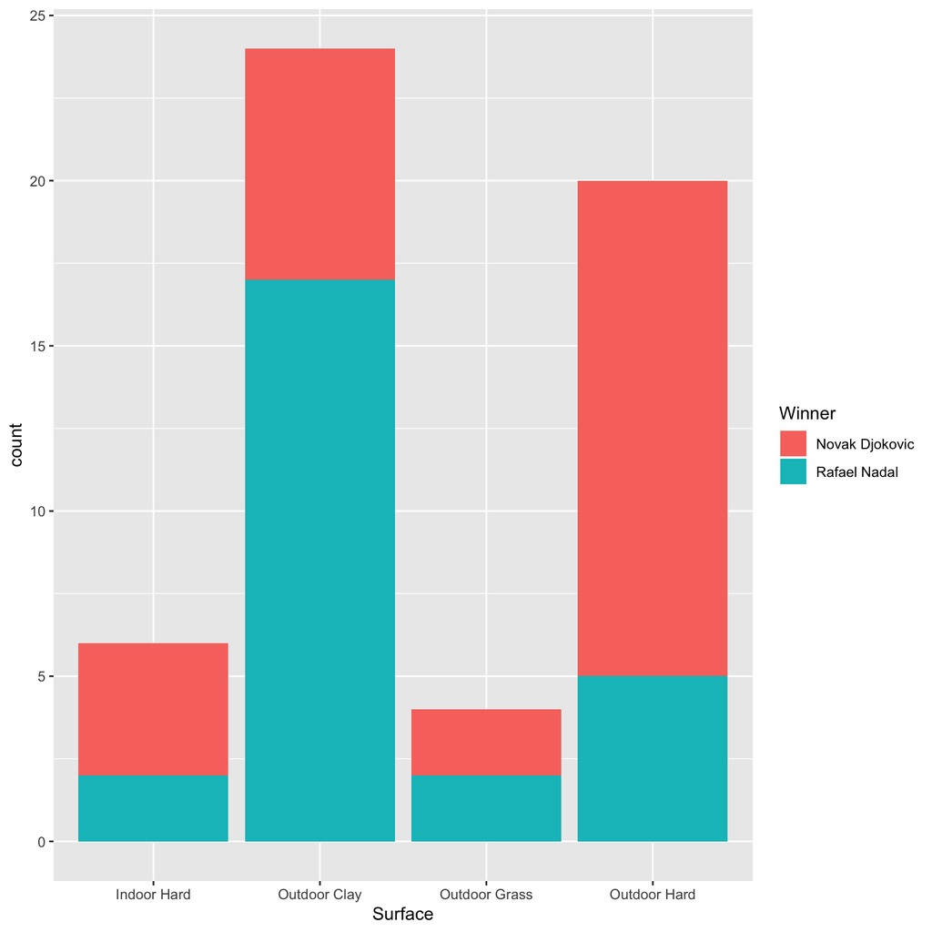

```r
ggplot(df, aes(x = Surface, fill = Winner)) + geom_bar()
```

### Changing the theme

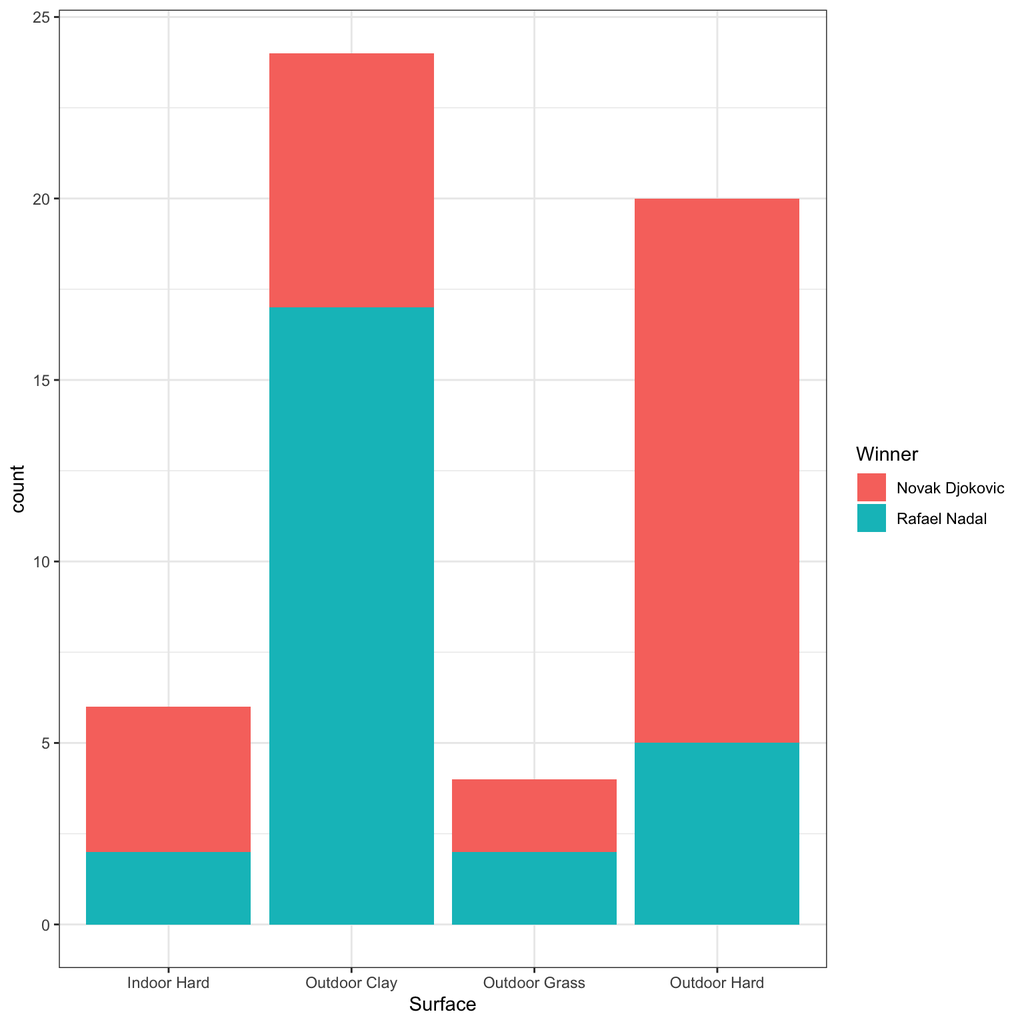

```r
ggplot(df, aes(x = Surface, fill = Winner)) + geom_bar() +
  theme_bw()
```

### Using the dodge position

Setting the position to “dodge” in *geom_bar* moves the pieces of a single bar to sit next to each other rather than to be stacked.

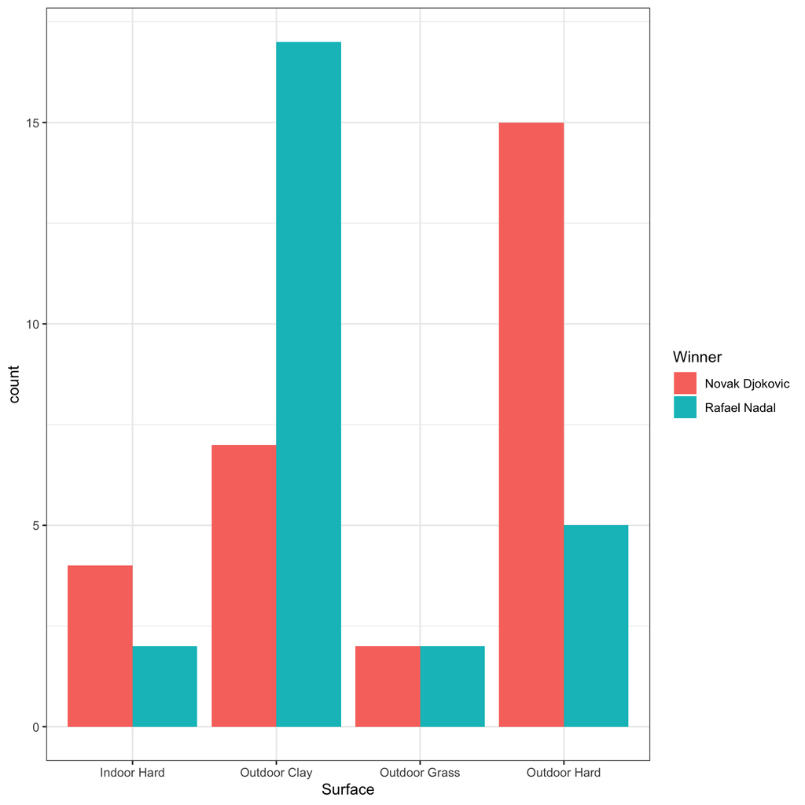

```r
ggplot(df, aes(x = Surface, fill = Winner)) +
  geom_bar(position = "dodge") +
  theme_bw()
```

### Using the fill position

Setting the position to “fill” in *geom_bar* keeps the pieces of each bar stack but the bars are normalised so that they are all the same height and the pieces of each bar reflect the percentage of the category.

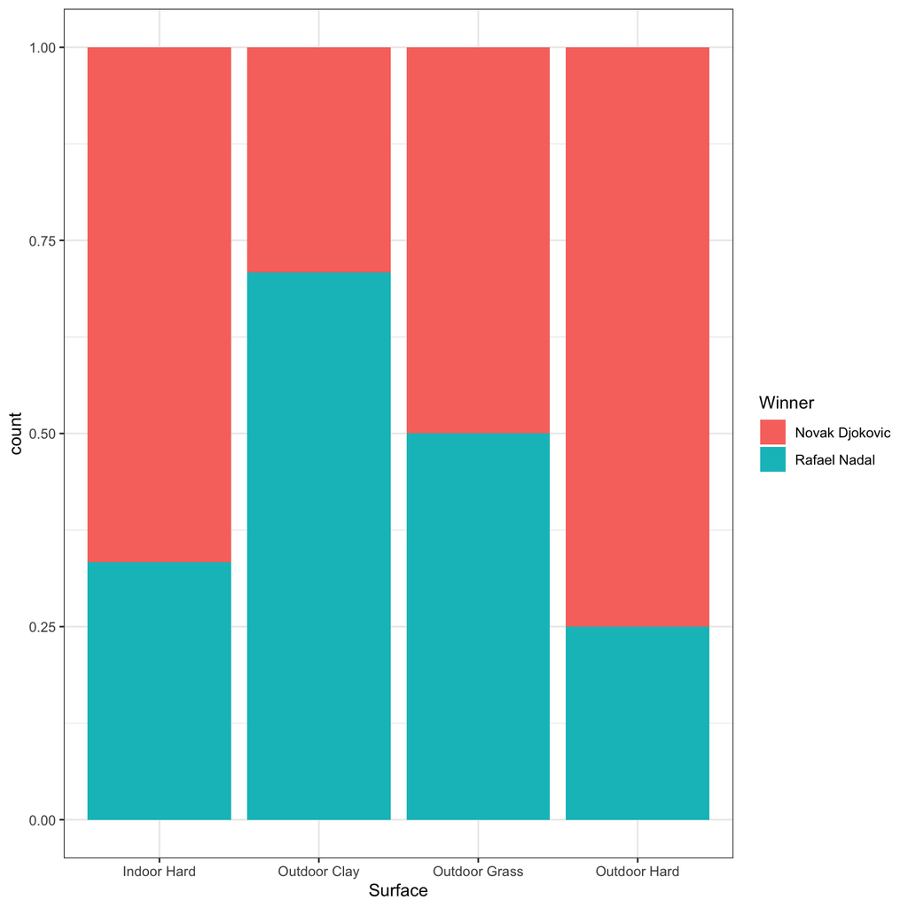

```r
ggplot(df, aes(x = Surface, fill = Winner)) +
  geom_bar(position = "fill") +
  theme_bw()
```

### Adding y-axis label and title

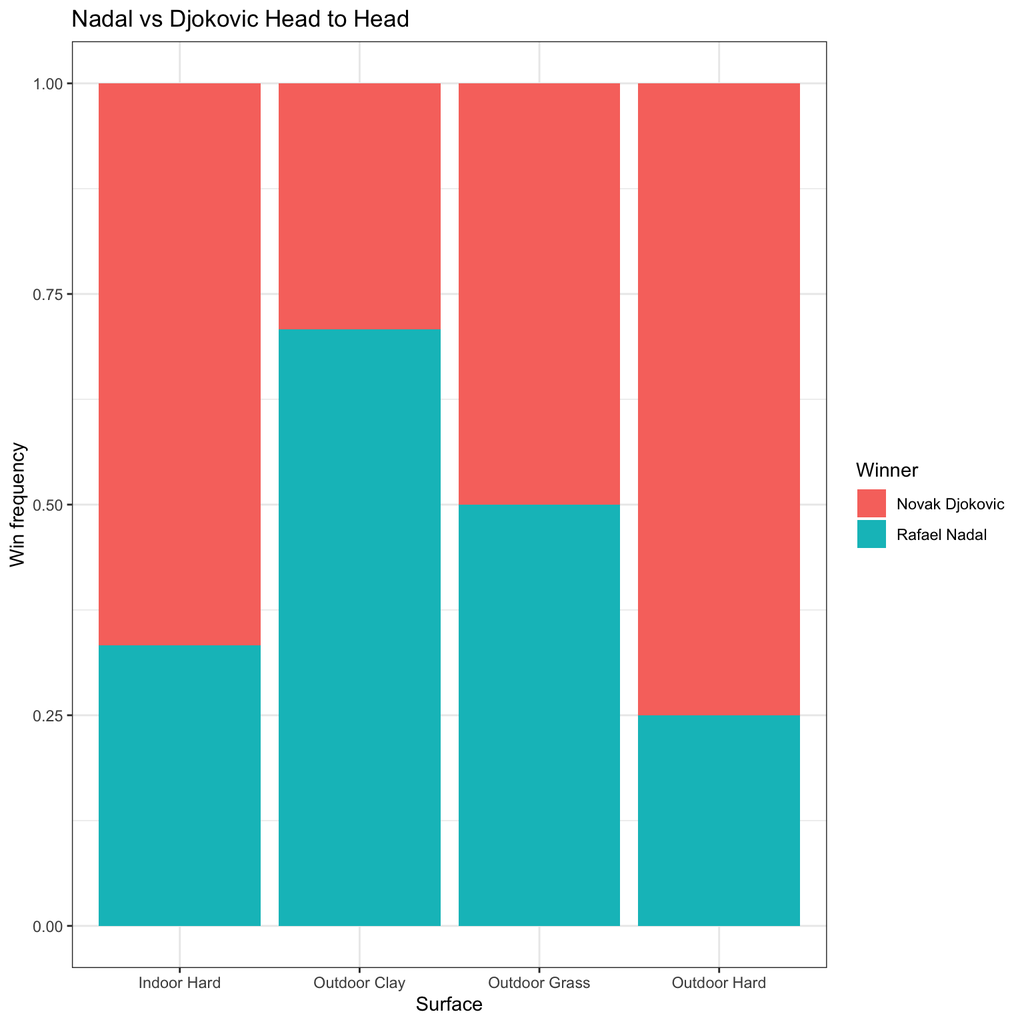

```r
ggplot(df, aes(x = Surface, fill = Winner)) +
  geom_bar(position = "fill") +
  theme_bw() + ylab("Win frequency") +
  ggtitle("Nadal vs Djokovic Head to Head")
```

### Centering the plot title

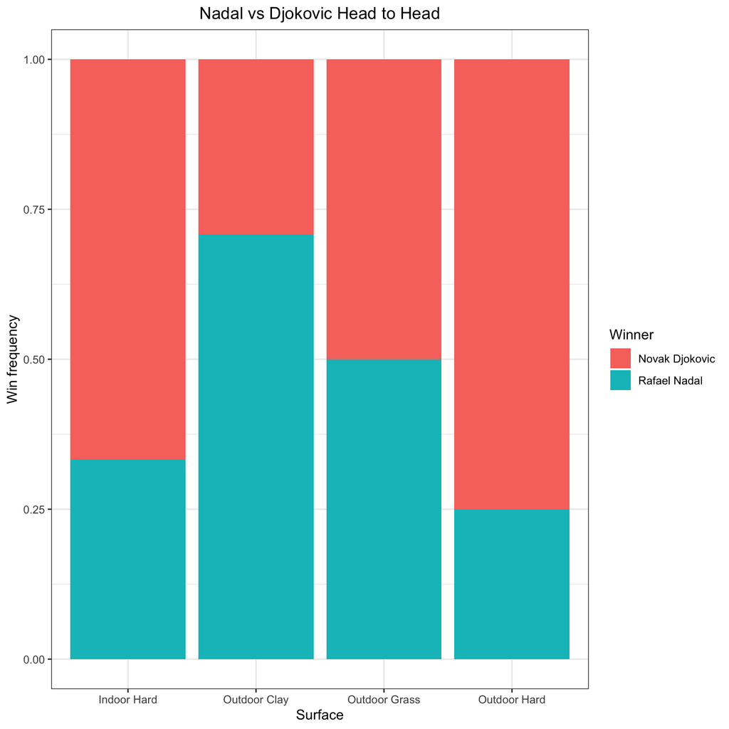

```r
ggplot(df, aes(x = Surface, fill = Winner)) +
  geom_bar(position = "fill") +
  theme_bw() + ylab("Win frequency") +
  ggtitle("Nadal vs Djokovic Head to Head") +
  theme(plot.title = element_text(hjust = 0.5))
```

### Changing the colour palette

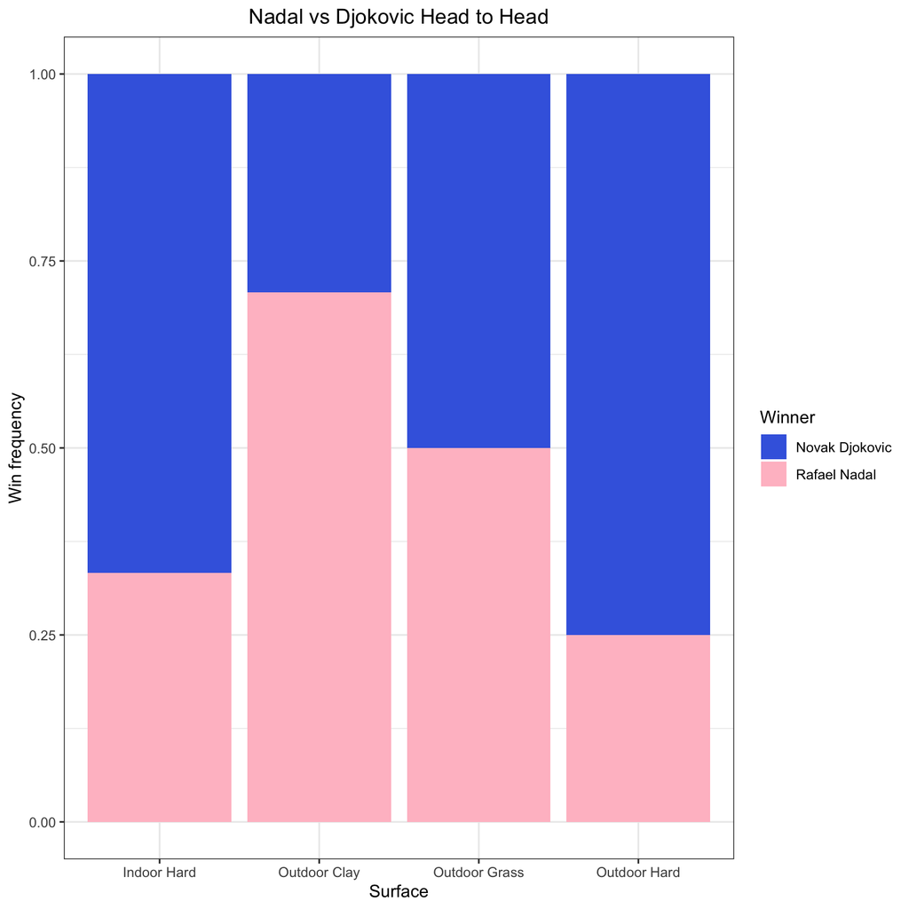

```r
ggplot(df, aes(x = Surface, fill = Winner)) +
  geom_bar(position = "fill") +
  theme_bw() + ylab("Win frequency") +
  ggtitle("Nadal vs Djokovic Head to Head") +
  theme(plot.title = element_text(hjust = 0.5)) +
  scale_fill_manual(values = c("royalblue", "pink"))
```

## Using facet_wrap

Before using `facet_wrap` let us first make a simple relative frequency bar chart from the *nycflights13* data set.

We will deal with 3 statuses of flights:

- on-time: the flight departed within 15 minutes of its scheduled departure
- delayed: the flight was delayed by more than 15 minutes
- cancelled: the flight was cancelled. These flights have *NA* values in both the departure delay and arrival delay columns.

First create a variable, determining if the flight was cancelled:

```r
library(nycflights13)
df2 <- flights
df2$cancelled <- ifelse(is.na(df2$dep_delay) & is.na(df2$arr_delay), "Cancelled", "Not cancelled")
```

Next, create a variable determining the overall status, using the following logic:

- if the flight was cancelled, then set the status to *cancelled*
- if the flight was not cancelled:
  - if the flight was delayed by more than 15 minutes, then set the status to *delayed*
  - otherwise the flight was *on time*

This can be done using the nested `ifelse`:

```r
df2$status <- ifelse(df2$cancelled == "Cancelled", "Cancelled",
                      ifelse(df2$dep_delay > 15, "Delayed", "On time"))
```

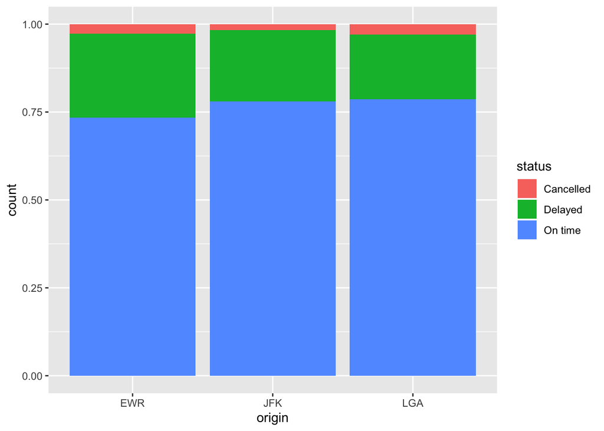

```r
ggplot(df2, aes(x = origin, fill = status)) +
  geom_bar(position = "fill")
```

#### Filtering down to the most common airlines

First, we get the names of the 5 most common airlines:

```r
major_airlines <- names(sort(table(df2$carrier), decreasing = TRUE)[1:5])
major_airlines
```

```
## [1] "UA" "B6" "EV" "DL" "AA"
```

Then filter the data down to only these airlines

```r
df3 <- dplyr::filter(df2, carrier %in% major_airlines)
```

### Centering title and changing title font size

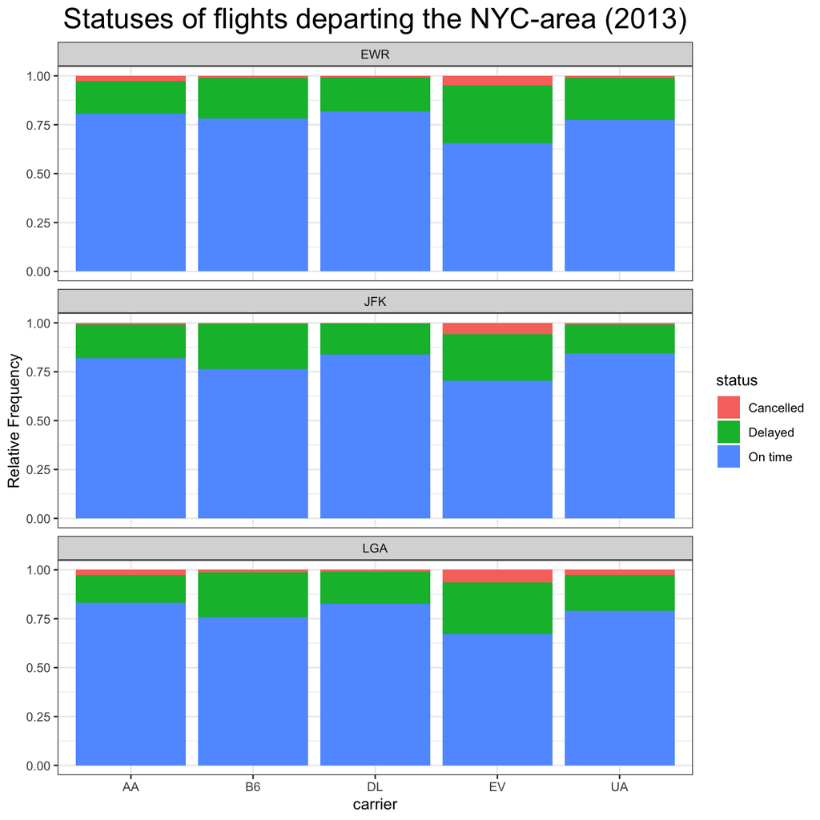

```r
ggplot(df3, aes(x = carrier, fill = status)) +
  geom_bar(position = "fill") +
  facet_wrap(~origin, ncol = 1) + ylab("Relative Frequency") +
  ggtitle("Statuses of flights departing the NYC-area (2013)") +theme_bw() +
  theme(plot.title = element_text(hjust = 0.5, size = 20))
```

### Getting the x-axis labels on all panels of the faceted plot

We can get ggplot to label the airlines in all 3 panels by making the x scale free:

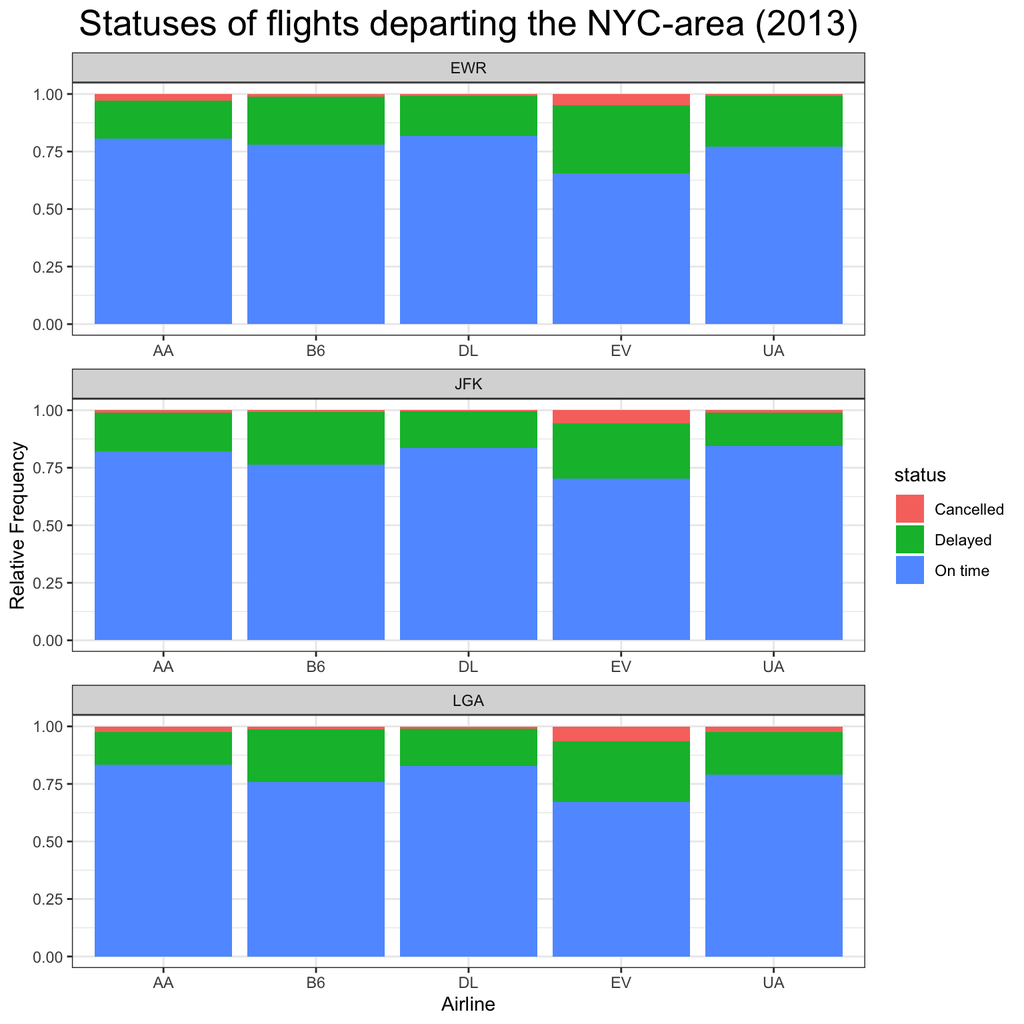

```r
ggplot(df3, aes(x = carrier, fill = status)) +
  geom_bar(position = "fill") +
  facet_wrap(~origin, ncol = 1, scale = "free_x") +
  ylab("Relative Frequency") +
  xlab("Airline") +
  ggtitle("Statuses of flights departing the NYC-area (2013)") +theme_bw() +
  theme(plot.title = element_text(hjust = 0.5, size = 20))
```